# Girls’ Day Workshop

### Übung 3.1

1. Erstelle ein Balkendiagramm, das zeigt, wie viele Kinder pro **Monat** geboren wurden.

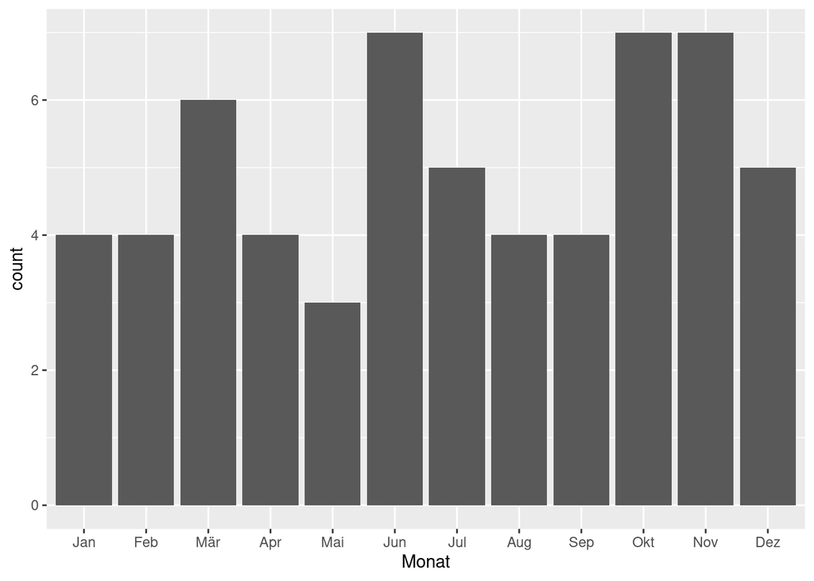

```r
df6 %>%
  ggplot(aes(x = Monat)) +
  geom_bar()
```

## Diagramme schön machen

Mit ggplot kannst du deine Diagramme anpassen, damit sie nicht so grau aussehen.

Du kannst die Balkenfarbe so ändern:

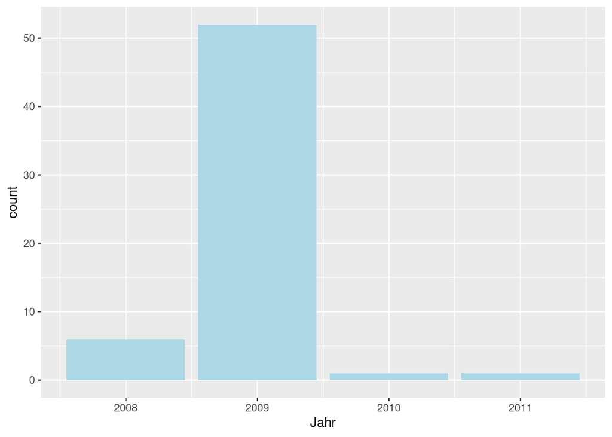

```r
df6 %>%
  ggplot(aes(x = Jahr)) +
  geom_bar(fill = "lightblue")
```

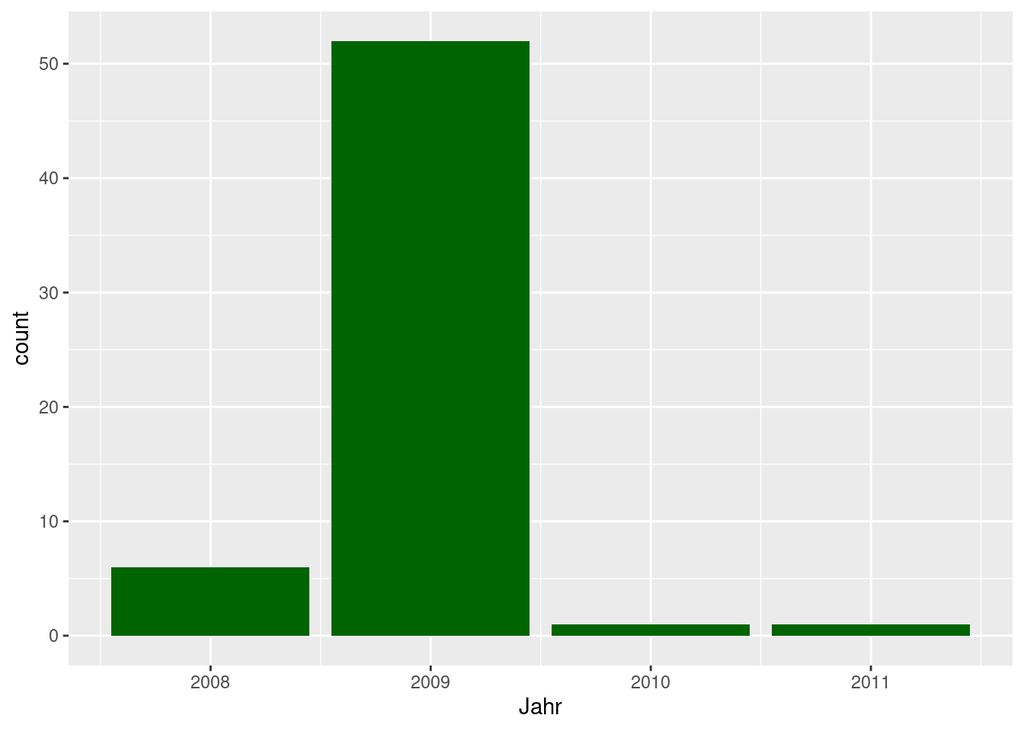

```r
df6 %>%
  ggplot(aes(x = Jahr)) +
  geom_bar(fill = "darkgreen")
```

Du kannst ihr auch einen Titel geben und die Achsenbeschriftung ändern.

Dafür gibt es die Funktion **labs()**.

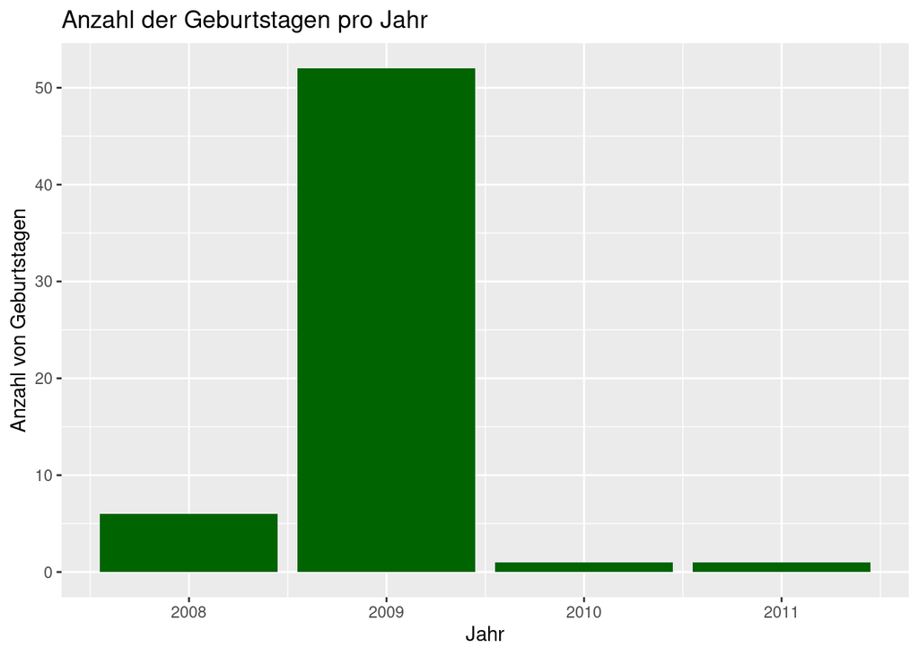

```r
df6 %>%
  ggplot(aes(x = Jahr)) +
  geom_bar(fill = "darkgreen") +
  labs(title = "Anzahl der Geburtstagen pro Jahr",
       x = "Jahr",
       y = "Anzahl von Geburtstagen")
```

### Übung 3.2

1. Füge dem Diagramm aus der vorherigen Übung einen Titel und Achsenbeschriftungen hinzu und ändere seine Farbe.

Du kannst alle Farbnamen hier finden: http://www.stat.columbia.edu/~tzheng/files/Rcolor.pdf

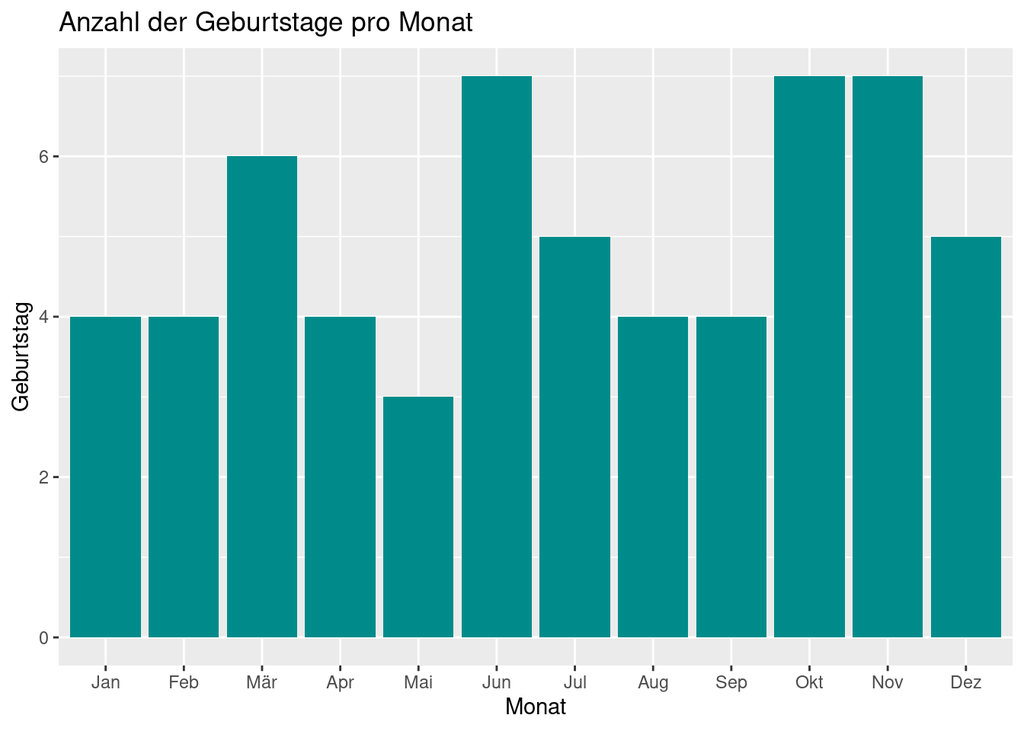

```r
df6 %>%
  ggplot(aes(x = Monat)) +
  geom_bar(fill = "cyan4") +
  labs(title = "Anzahl der Geburtstage pro Monat",
     x = "Monat",
     y = "Geburtstag")
```

## Komplexe Balkendiagramme

Nehmen wir an, wir wollen die **Geburtsjahre** nach **Geschlecht** vergleichen.

Das kann man mit der Funktion **aes()** machen.

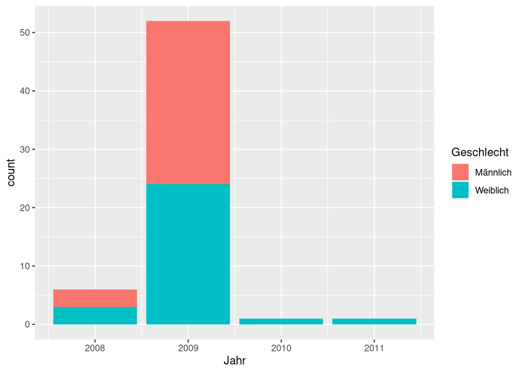

```r
df6 %>%
  ggplot(aes(x = Jahr, fill = Geschlecht)) +
  geom_bar()
```

Jetzt haben wir eine Legende auf der rechten Seite unseres Diagramms.

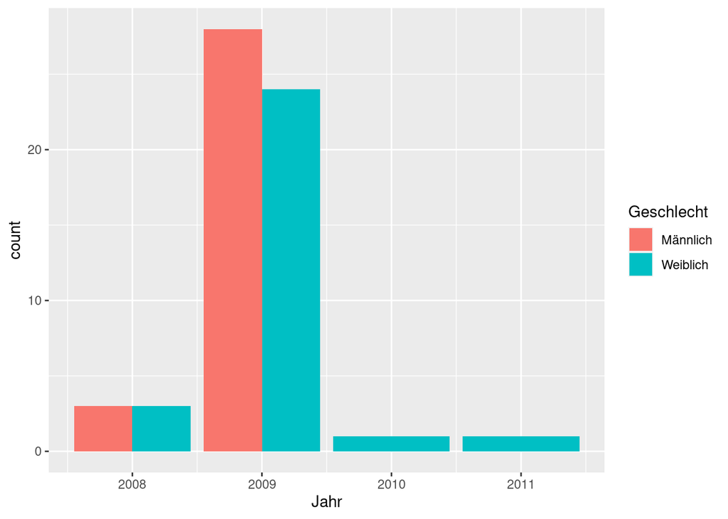

```r
df6 %>%
  ggplot(aes(x = Jahr, fill = Geschlecht)) +
  geom_bar(position = position_dodge())
```

Wenn du ein Diagramm mit einer Legende erstellt, kannst du die Farben nicht mit geom_bar(fill = “farbe”) ändern.

Stattdessen nutzt man die Funktion **scale_fill_manual()**.

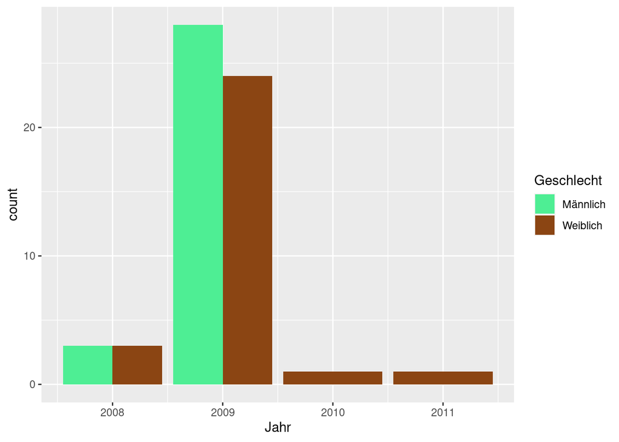

```r
df6 %>%
  ggplot(aes(x = Jahr, fill = Geschlecht)) +
  geom_bar(position = position_dodge()) +
  scale_fill_manual(values = c("seagreen2", "chocolate4"))
```

### Übung 3.3

1. Erstelle ein Balkendiagramm mit einer Legende, um die folgende Frage zu beantworten: “Wie viele Geburtstage gibt es pro **Monat** und pro **Klasse**?”
2. Füge dem Diagramm einen Titel und Achsenbeschriftungen hinzu und ändere seine Farben.

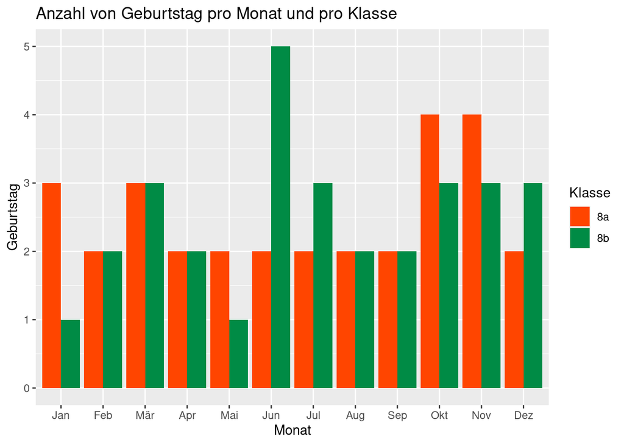

```r
df6 %>%
  ggplot(aes(x = Monat, fill = Klasse)) +
  geom_bar(position = position_dodge()) +
  scale_fill_manual(values = c("orangered", "springgreen4")) +
  labs(title = "Anzahl von Geburtstag pro Monat und pro Klasse",
       x = "Monat",
       y = "Geburtstag")
```

## Tidyverse und ggplot

### Übung 3.4

Deiner Meinung nach, wie kann man ein Balkendiagramm für die folgende Frage erstellen?

“Wie viele Kinder der **Klasse 8b** wurden pro **Monat** und pro **Geschlecht** geborden?”

**Hinweis:** Du musst deinen Datensatz mit einer Tidyverse Funktion bearbeiten, bevor du dein Diagramm erstellen kannst.

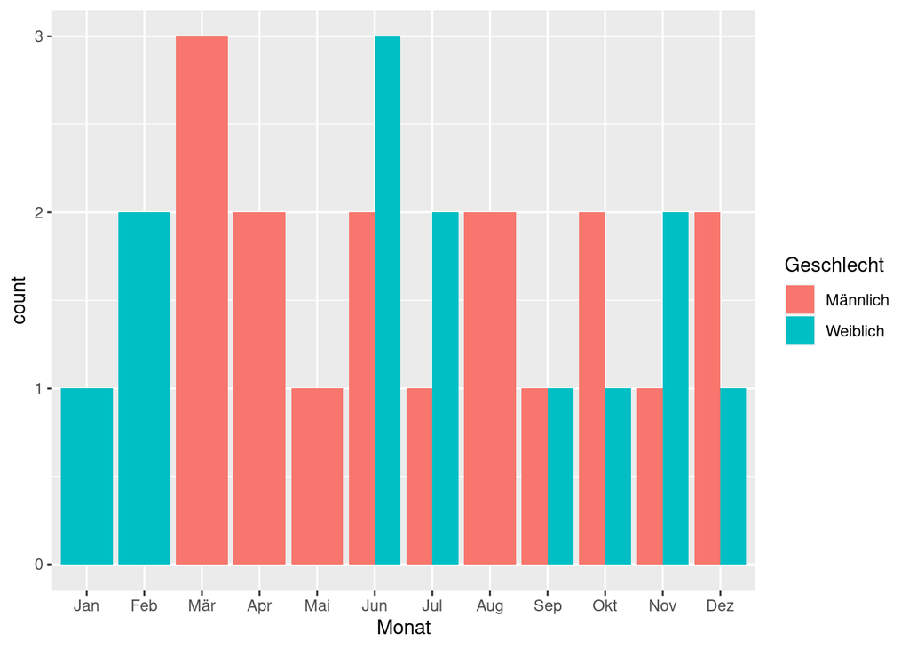

```r
df6 %>%
  filter(Klasse == "8b") %>%

  ggplot(aes(x = Monat, fill = Geschlecht)) +
  geom_bar(position = position_dodge())
```